# Klasse-D slides

Klasse D versterkers

Hoogfrequent versterkers  
met 2 vermogentransistors

Jan Genoe

October 2025

###### Klasse D versterker

- Combinatie van:
  - een balansschakeling (zie klasse B)
  - een resonante L-C kring (zie klasse C)
- Kan enkel vermogen leveren op de resonantiefrequentie van de kring
- Sturing gebeurt aan de hand van een blokgolf op de resonantiefrequentie
  - Dit houdt in dat de transistors gebruikt worden als schakelaars)
- Enkel de eerste harmonische komt ongehinderd door naar de belasting
  - Dit kan enkel maar voor een resonante versterker

###### Basisschema van de klasse D versterker

[figure not shown]

###### Stromen en spanningen

- Er wordt geschakeld als de stroom door de inductantie 0 is
- Spanning over de transistor
  - ongeveer 0 Volt in geval de transistor stroom geleidt
  - Voedingsspanning in het geval de transistor geen stroom geleidt
- Stroom door de transistor : Afwisselend
  - een halve periode stroom (sinus)
  - een halve periode geen stroom

###### Klasse D versterker met MOS transistors in GSS

[figure not shown]

###### Basisschema van de klasse D versterker met nummering van de knopen

[figure not shown]

###### SPICE file Klasse D circuit

```
* Class D amp 1
Q_Q1         3 1 2 Q2
Q_Qp         0 1 2 Qp
L_L1         5 2 1uH
C_C1         5 6 10n
R_RL         6 0 6
V_Vdd        3 0 20V
R_Rin        4 1 1
V_Vin        4 0 PULSE(0 20 0 20ns 20ns 294ns 628ns) DC=0
.model Q2  NPN(Is=14.34f BF=200)
.model Qp  PNP(Is=5.34f BF=100)
```

###### Bekomen spanningen op de verschillende knopen

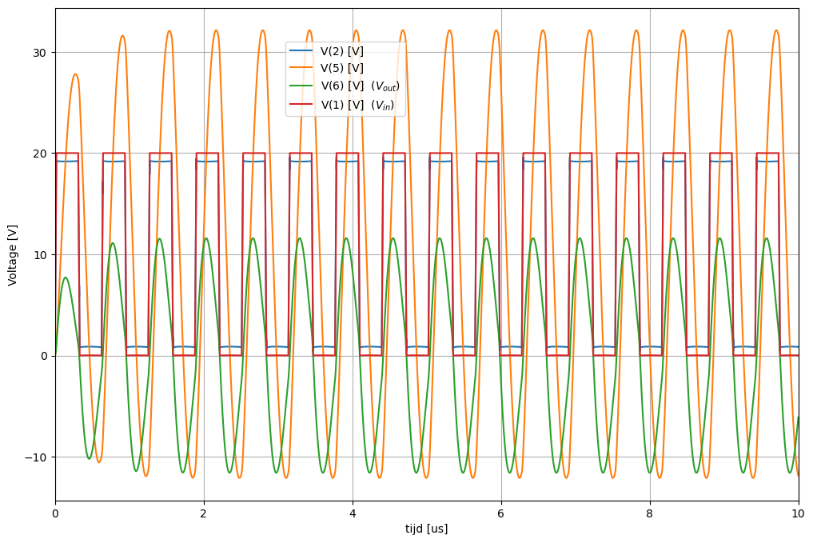

###### Collector stroom in de NPN en de PNP transistor

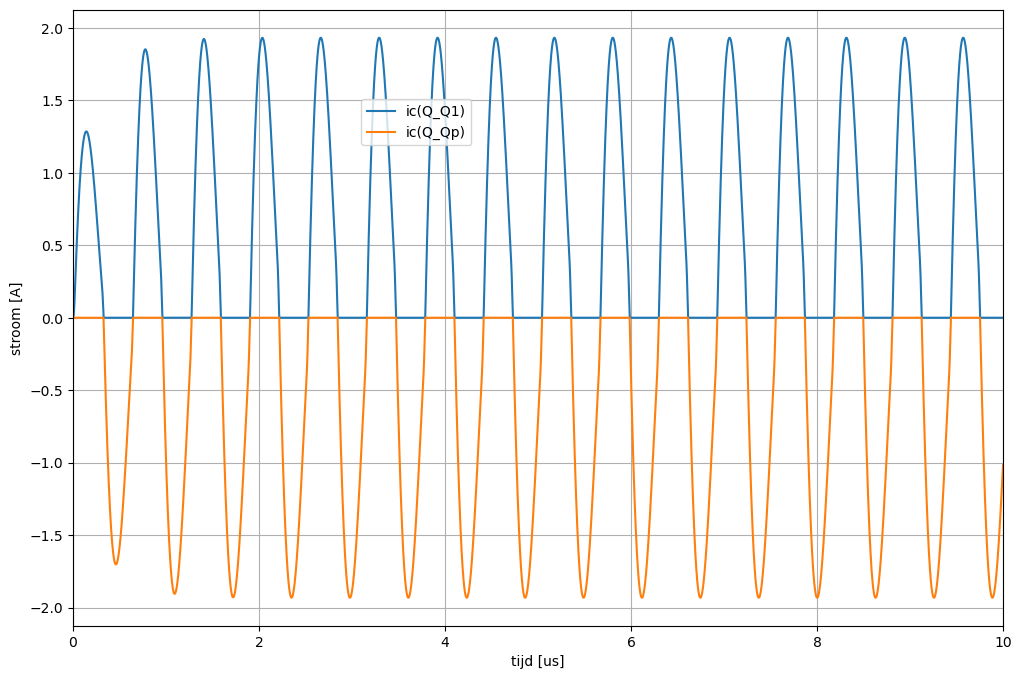

###### Fourrier reeks

De Fourier reeks van de spanning op knoop 2 is:

###### Fourrier reeks van de spanning op knoop 2

$$ V[2] = \frac{V_{dd}}{2} +\frac{2 V_{dd}}{\pi}\left(\sin(\omega t) +\frac{\sin(3\omega t)}{3} +\frac{\sin(5\omega t)}{5} + ... \right)$$

###### Fourrier reeks van de blokgolf

- Heeft geen even harmonische componenten
- Oneven hogere harmonische componenten
  - dalen sterk met de frequentie
  - zien ook een veel hogere impedantie

Dus, de harmonische bijdrage is klein, maar niet onbestaande (hangt af van de kwaliteit van de kring)

###### Nuttig vermogen

- Bekomen spanning over R<sub>L</sub> is de amplitude van de eerste harmonische van de blokgolf.
  - Dit houdt in dat amplitude modulatie alleen maar kan bekomen worden door plaatmodulatie
- Deze amplitude bedraagt:
- Het nuttig vermogen is dus:

$$ V_{R_L}= \frac{2 V_{DD}}{\pi} $$

$$ P_{R_L}= \frac{2 V^2_{DD}}{\pi^2 R_L} $$

###### Opgestapelde energie

- De amplitude over R<sub>L</sub> zegt niets over de amplitude over L<sub>1</sub> (en dus ook tegengesteld over C<sub>1</sub>)
- Deze amplitude wordt bepaald door de kwaliteitsfactor (Q) van de kring, dit is de verhouding tussen de opgestapelde energie en de vrijgegeven energie.

$$ Q= \frac{\omega L_1}{R_L} = \frac{\text{opgestapelde energie}}{\text{vrijgegeven energie}}$$

###### Harmonische componenten in de spanning

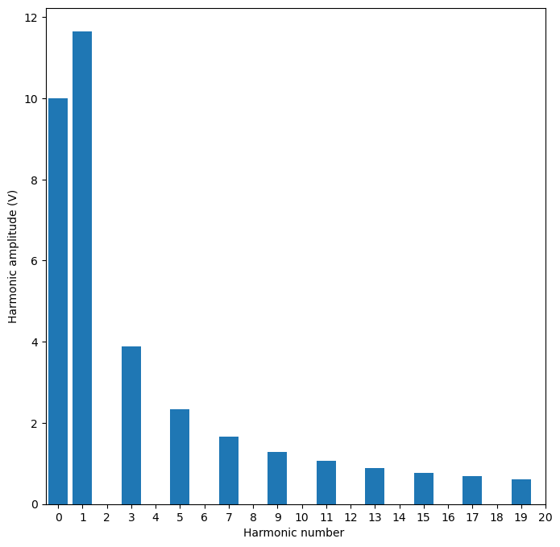

###### impedantie van de serie trilkring

###### impedantie van de serie trilkring

$$Z(\omega) = j \omega L_1 +\frac{1}{j \omega C_1} + R_L $$

###### Harmonische componenten van de uitgangsstroom

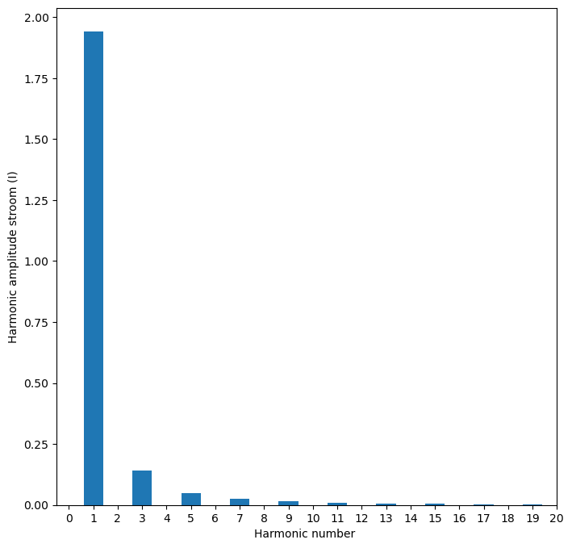

###### Harmonische componenten van de uitgangsstroom (logschaal)

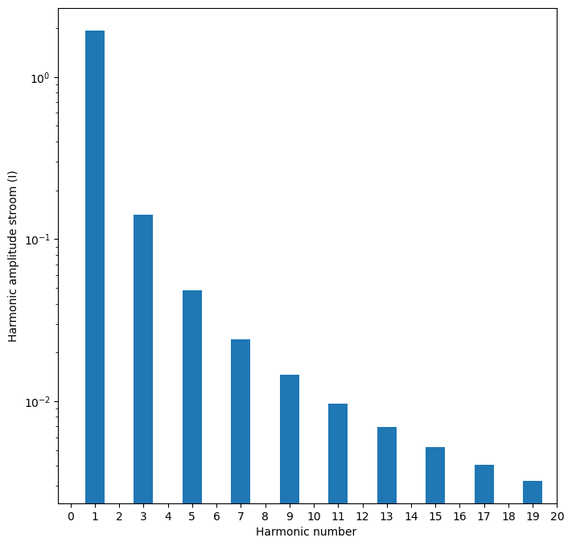

###### Rendement

- Theoretisch 100%
- Lager door
  - (Beperkte) stroom in de harmonischen
  - Schakelverliezen
    - Bepaald door de ladingsopslag q in het actief element
    - Evenredig met q<sup>2</sup>
    - Evenredig met de schakelfrequentie
  - Spanningsval
    - bipolaire componenten: vaste spanning
    - veldeffect componenten: vaste weerstand

###### Basisschema van de klasse D versterker met beschermdiodes

[figure not shown]

###### SPICE file Klasse D circuit met diodes

```
* Class D amp 1
Q_Q1         3 1 2 Q2
Q_Qp         0 1 2 Qp
D_D1         2 3 DD
D_D2         0 2 DD
L_L1         5 2 1uH
C_C1         5 6 10n
R_RL         6 0 6
V_Vdd        3 0 20V
R_Rin        4 1 1
V_Vin        4 0 PULSE(0 20 0 20ns 20ns 280ns 600ns) DC=0
.model Q2  NPN(Is=14.34f BF=200)
.model Qp  PNP(Is=5.34f BF=100)
.model DD   D( IS=0.0002 RS=0.05 CJO=5e-10 )
```

###### Bekomen spanningen in de Klasse D versterker met diodes

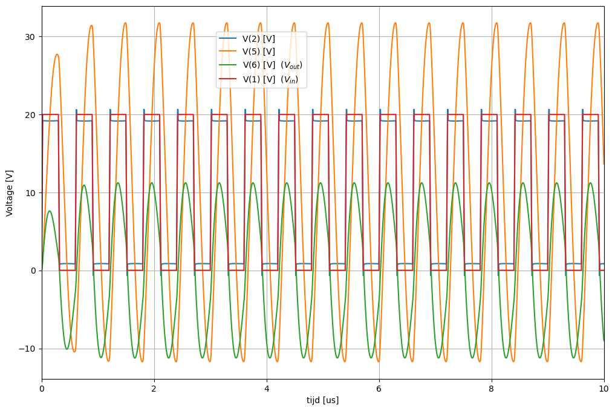

###### Detail van de spanningen

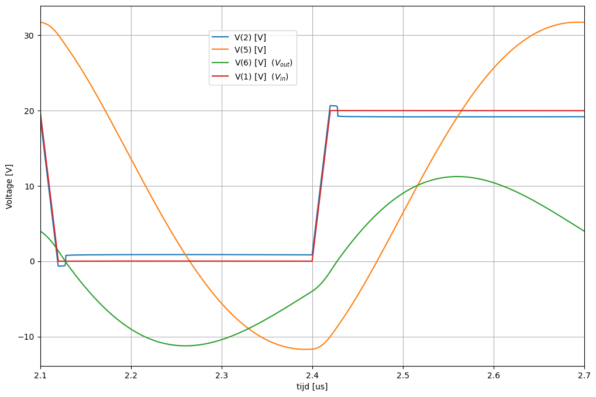

###### Stromen in de transistors en diodes

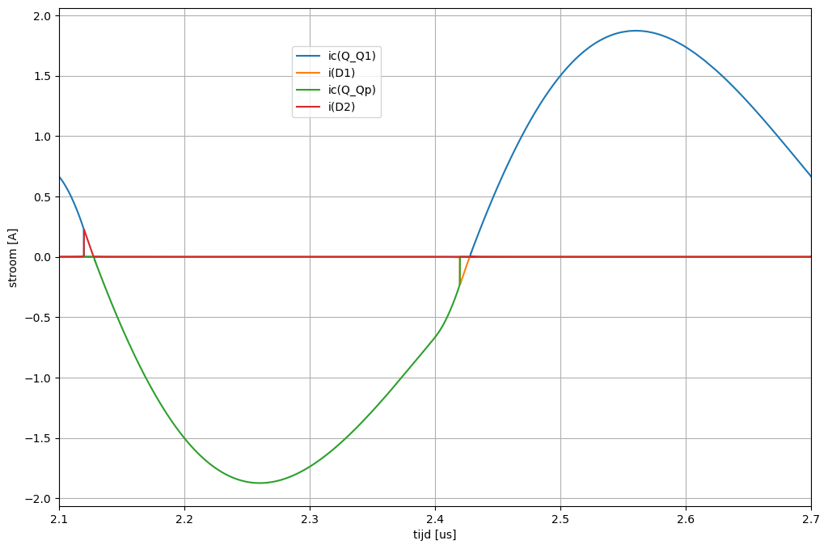

###### Klasse D versterker met enkel NPN transistors

[figure not shown]

###### Klasse D versterker met enkel NPN transistors

[figure not shown]

###### Klasse D versterker met spanningssturing

[figure not shown]

###### Keuze wikkelverhouding transformator

[figure not shown]

###### Klasse D versterker met spanningssturing en beveiligingsdiodes

[figure not shown]

###### Met stroomsturing

[figure not shown]

###### Met stroomsturing en beveiligingsdiodes

[figure not shown]

I would rather have questions that can't be answered  
than answers that can't be questioned.

Richard Feynman